# MODEL DEVELOPMENT

###### By [Bienvenu CHOUPO](https://www.linkedin.com/in/bienvenu-choupo), October 26 2019

Remember the automobile data set and the exploratory analysis we made? You can check it [HERE](https://bienvenuc.github.io/MyProjects/EDA_cars.html)  
You can also view the [INTERACTIVE VISUALIZATION DASHBOARD](https://mybinder.org/v2/gh/BienvenuC/Bokeh-Visualization/master?urlpath=/proxy/5006/bokeh-app) we made

We saw that the best predictors of the price of a car were the following variables:

Continuous numerical variables:

- Length
- Width
- Curb_weight
- Engine_size
- Horsepower
- City_mpg
- Highway_mpg
- Wheel_base
- Bore

Categorical variables:

- Drive_wheels

In this document, we will develop several models that will predict the price of the car using the variables or features. This is just an estimate but should give us an objective idea of how much the car should cost.

Some questions we want to ask in this document

- do I know if the dealer is offering fair value for my trade-in?
- do I know if I put a fair value on my car?

In Data Analytics, we often use **Model Development** to help us predict future observations from the data we have.

A Model will help us understand the exact relationship between different variables and how these variables are used to predict the result.

Here is the plan we will follow:

#### 1. Linear Regression and Multiple Linear Regression

#### 2. Model Evaluation using Visualization

#### 3. Polynomial Regression and Pipelines

#### 4. Measures for In-Sample Evaluation

#### 5. Prediction and Decision Making

#### 6. Conclusion

Let's load the data and store in dataframe df:

|  | price | length | width | curb_weight | engine_size | horsepower | city_mpg | highway_mpg | wheel_base | bore | drive_wheels |
| --- | --- | --- | --- | --- | --- | --- | --- | --- | --- | --- | --- |
| 0 | 13495.0 | 0.811148 | 0.890278 | 2548 | 130 | 111.0 | 21 | 27 | 88.6 | 3.47 | rwd |
| 1 | 16500.0 | 0.811148 | 0.890278 | 2548 | 130 | 111.0 | 21 | 27 | 88.6 | 3.47 | rwd |
| 2 | 16500.0 | 0.822681 | 0.909722 | 2823 | 152 | 154.0 | 19 | 26 | 94.5 | 2.68 | rwd |
| 3 | 13950.0 | 0.848630 | 0.919444 | 2337 | 109 | 102.0 | 24 | 30 | 99.8 | 3.19 | fwd |
| 4 | 17450.0 | 0.848630 | 0.922222 | 2824 | 136 | 115.0 | 18 | 22 | 99.4 | 3.19 | 4wd |

## 1. Linear Regression and Multiple Linear Regression

### 1.1. Linear Regression

One example of a Data Model that we will be using is **Simple Linear Regression**.

Simple Linear Regression is a method to help us understand the relationship between two variables:

- The predictor/independent variable (X)
- The response/dependent variable (that we want to predict)(Y)

The result of Linear Regression is a **linear function** that predicts the response (dependent) variable as a function of the predictor (independent) variable.

$$ Y: Response \ Variable\\ X: Predictor \ Variables $$

**Linear function:** $$ Yhat = a + b X $$

- a refers to the **intercept** of the regression line0, in other words: the value of Y when X is 0
- b refers to the **slope** of the regression line, in other words: the value with which Y changes when X increases by 1 unit

Let's create the linear regression object

```
LinearRegression(copy_X=True, fit_intercept=True, n_jobs=None, normalize=False)
```

We noticed in our [EDA](https://bienvenuc.github.io/MyProjects/EDA_cars.html) that Engine_size showed a strong correlation with Price.

#### How could Engine_size help us predict car price?

Using simple linear regression, we will create a linear function with "engine_size" as the predictor variable and the "price" as the response variable.

```
LinearRegression(copy_X=True, fit_intercept=True, n_jobs=None, normalize=False)
```

We can output a prediction

```
array([13728.4631336 , 13728.4631336 , 17399.38347881, 10224.40280408,
       14729.62322775])
```

#### What is the value of the intercept (a)?

```
-7963.338906281042
```

#### What is the value of the Slope (b)?

```
array([166.86001569])
```

### What is the final estimated linear model we get?

As we saw above, we should get a final linear model with the structure: $$Yhat = a + b X $$

Plugging in the actual values we get:

[output not shown]

### 1.2. Multiple Linear Regression

What if we want to predict car price using more than one variable? In fact we need to use more than just only one variable

we can use **Multiple Linear Regression** which is very similar to Simple Linear Regression.

From our previous [Exploratory Data Analysis](https://bienvenuc.github.io/MyProjects/EDA_cars.html) we know that other good predictors of price could be:

- Length
- Width
- Curb_weight
- Engine_size
- Horsepower
- City_mpg
- Highway_mpg
- Wheel_base
- Bore

Let's develop a model using these 9 variables as the predictor variables.

The equation is given by: $$Yhat = a + b_1 X_1 + ... + b_9 X_9$$ Where $a$ is the intercept, $b_i$ is the coefficient of variable $X_i, i=1,2,...,9$

```
LinearRegression(copy_X=True, fit_intercept=True, n_jobs=None, normalize=False)
```

What is the value of the intercept(a)?

```
-49160.92214673396
```

What are the values of the coefficients (b1, b2,..., b9)?

```
array([-1.50480466e+04,  4.57095843e+04,  3.11955137e+00,  5.93854041e+01,
        7.90716126e+01, -1.70102788e+02,  1.84019817e+02,  1.11785381e+02,
       -1.02643761e+03])
```

What is the final estimated linear model that we get?

## 2. Model Evaluation using Visualization

Now that we've developed some models, how do we evaluate our models and how do we choose the best one? One way to do this is by using visualization.

### 2.1. Using Regression Plot

When it comes to simple linear regression, an excellent way to visualize the fit of our model is by using **regression plots**.

This plot will show a combination of a scattered data points (a **scatter plot**), as well as the fitted **linear regression** line going through the data. This will give us a reasonable estimate of the relationship between the two variables, the strength of the correlation, as well as the direction (positive or negative correlation).

```
(0, 55832.77649206348)
```

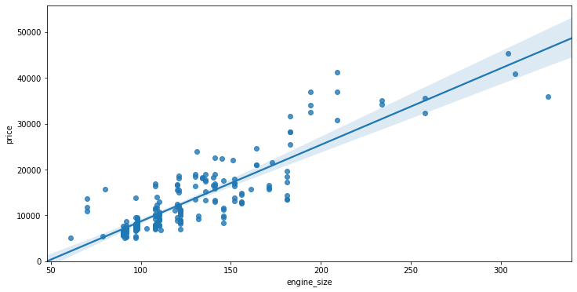

We can see from this plot that price is positively correlated to engine_size, since the regression slope is positive. Paying attention to this scatter plot and how the data points are scatter around the regression line, we can say that the linear model is good for predicting the price of a car when using engine_size as a predictor, but might not be the best

### 2.2. Using Residual Plot

In order to visualize the variance of the data, let's use a residual plot.

The difference between the observed value (y) and the predicted value (Yhat) is called the residual (e). When we look at a regression plot, the residual is the distance from the data point to the fitted regression line.

A residual plot is a graph that shows the residuals on the vertical y-axis and the independent variable on the horizontal x-axis.

What do we pay attention to when looking at a residual plot?

We look at the spread of the residuals:

- If the points in a residual plot are **randomly spread out around the x-axis**, then a **linear model is appropriate** for the data. Why is that? Randomly spread out residuals means that the variance is constant, and thus the linear model is a good fit for this data.

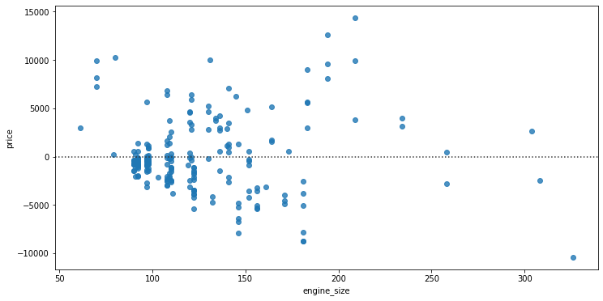

*What is this plot telling us?*

We can see from this residual plot that the residuals are not randomly spread around the x-axis, which leads us to believe that maybe a non-linear model is more appropriate for this data.

### 2.3. Evaluating Multiple Linear Regression: Distribution Plot

How do we visualize a model for Multiple Linear Regression? This gets a bit more complicated because you can't visualize it with regression or residual plot.

One way to look at the fit of the model is by looking at the **distribution plot**: We can look at the distribution of the fitted values that result from the model and compare it to the distribution of the actual values.

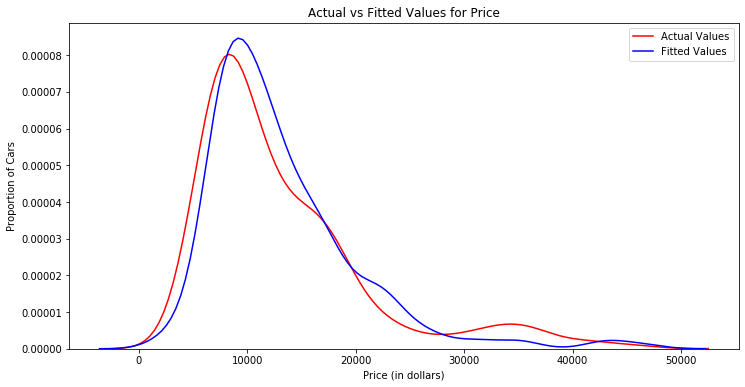

We can see that the fitted values are reasonably close to the actual values, since the two distributions overlap a bit. However, there is definitely some room for improvement.

## 3. Polynomial Regression and Pipelines

### 3.1. Polynomial Regression

**Polynomial regression** is a particular case of the general linear regression model or multiple linear regression models.

We get non-linear relationships by squaring or setting higher-order terms of the predictor variables.

There are different orders of polynomial regression:

Quadratic - 2nd order: $Yhat = a + b_1 X^2 +b_2 X^2 $

Cubic - 3rd order: $Yhat = a + b_1 X^2 +b_2 X^2 +b_3 X^3$

Higher order: $Yhat = a + b_1 X^2 +b_2 X^2 +b_3 X^3 ....$

We saw earlier that a linear model did not provide the best fit while using engine_size as the predictor variable. Let's see if we can try fitting a polynomial model to the data instead.

Let's fit the polynomial using the function **polyfit**, then use the function **poly1d** to display the polynomial function.  
Here we use a polynomial of the 3rd order (cubic)

```
           3         2
-0.006641 x + 3.645 x - 433.4 x + 2.208e+04
```

Let's plot the function

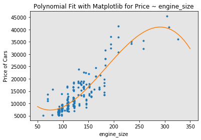

```
array([-6.64112463e-03,  3.64536744e+00, -4.33383781e+02,  2.20846740e+04])
```

We can already see from plotting that this polynomial model performs better than the linear model. This is because the generated polynomial function "hits" more of the data points.

The analytical expression for Multivariate Polynomial function gets complicated. For example, the expression for a second-order (degree=2)polynomial with two variables is given by:

$$ Yhat = a + b_1 X_1 +b_2 X_2 +b_3 X_1 X_2+b_4 X_1^2+b_5 X_2^2 $$

We can perform a polynomial transform on multiple features.

We create a **PolynomialFeatures** object of degree 2 and fit it:

```
PolynomialFeatures(degree=2, include_bias=True, interaction_only=False,
                   order='C')
```

The original data is of 201 samples and 9 features

```
(201, 9)
```

After the transformation, there are 201 samples and 55 features

```
(201, 55)
```

### 3.2. Pipelines

Data Pipelines simplify the steps of processing the data. We use the module **Pipeline** to create a pipeline. We also use **StandardScaler** as a step in our pipeline.

We create the pipeline, by creating a list of tuples including the name of the model or estimator and its corresponding constructor.

We input the list as an argument to the pipeline constructor

```
Pipeline(memory=None,
         steps=[('scale',
                 StandardScaler(copy=True, with_mean=True, with_std=True)),
                ('polynomial',
                 PolynomialFeatures(degree=2, include_bias=False,
                                    interaction_only=False, order='C')),
                ('model',
                 LinearRegression(copy_X=True, fit_intercept=True, n_jobs=None,
                                  normalize=False))],
         verbose=False)
```

We can normalize the data, perform a transform and fit the model simultaneously.

```
Pipeline(memory=None,
         steps=[('scale',
                 StandardScaler(copy=True, with_mean=True, with_std=True)),
                ('polynomial',
                 PolynomialFeatures(degree=2, include_bias=False,
                                    interaction_only=False, order='C')),
                ('model',
                 LinearRegression(copy_X=True, fit_intercept=True, n_jobs=None,
                                  normalize=False))],
         verbose=False)
```

Similarly, we can normalize the data, perform a transform and produce a prediction simultaneously

```
array([12572.65380251, 12572.65380251, 14799.61323639, 11438.6771696 ])
```

## 4. Measures for In-Sample Evaluation

When evaluating our models, not only do we want to visualize the results, but we also want a quantitative measure to determine how accurate the model is.

Two very important measures that are often used in Statistics to determine the accuracy of a model are:

- **R^2 / R-squared**
- **Mean Squared Error (MSE)**

**R-squared** also known as the coefficient of determination, is a measure to indicate how close the data is to the fitted regression line.

The value of the R-squared is the percentage of variation of the response variable (y) that is explained by a linear model.

**Mean Squared Error (MSE)** measures the average of the squares of errors, that is, the difference between actual value (y) and the estimated value (ŷ).

### 4.1. Model 1: Simple Linear Regression

Let's calculate the R^2

```
The R-square is:  0.7609686443622008
```

We can say that ~ 76.097% of the variation of the price is explained by this simple linear model "engine_size_fit".

Let's calculate the MSE

We can predict the output i.e., "yhat" using the predict method, where X is the input variable:

```
The output of the first four predicted value is:  [13728.4631336  13728.4631336  17399.38347881 10224.40280408]
```

We compare the predicted results with the actual results

```
The mean square error of price and predicted value is:  15021126.025174143
```

### 4.2. Model 2: Multiple Linear Regression

Let's calculate the R^2

```
The R-square is:  0.8190477325381927
```

We can say that ~ 81.905 % of the variation of price is explained by this multiple linear regression "multi_fit".

Let's calculate the MSE:

We produce a prediction and compare the predicted results with the actual results

```
The mean square error of price and predicted value using multi_fit is:  11371339.993584491
```

### 4.3. Model 3: Polynomial Fit

Let's calculate the R^2

We apply the function " r2_score" to get the value of r^2

```
The R-square value is:  0.7901519931574331
```

### MSE

We can also calculate the MSE:

```
13187196.083555732
```

## 5. Prediction and Decision Making

### 5.1. Prediction

In the previous section, we trained the model using the method **fit**. Now we will use the method **predict** to produce a prediction. Lets import **pyplot** for plotting; we will also be using some functions from numpy.

Create a new input

Fit the model

```
LinearRegression(copy_X=True, fit_intercept=True, n_jobs=None, normalize=False)
```

Produce a prediction

```
array([-7796.47889059, -7629.6188749 , -7462.75885921, -7295.89884352,
       -7129.03882782])
```

Then we can plot the data

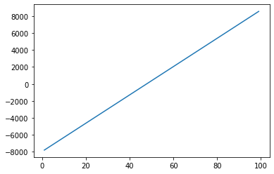

### 5.2. Decision Making: Determining a Good Model Fit

Now that we have visualized the different models, and generated the R-squared and MSE values for the fits, how do we determine a good model fit?

- *What is a good R-squared value?*

When comparing models, **the model with the higher R-squared value is a better fit** for the data.

- *What is a good MSE?*

When comparing models, **the model with the smallest MSE value is a better fit** for the data.

#### Let's take a look at the values for the different models.

Simple Linear Regression: Using engine_size as a Predictor Variable of Price.

- R-squared: 0.7609686443622008
- MSE: 1.50 x 10^7

Multiple Linear Regression: Using Length, Width, Curb_weight, Engine_size, Horsepower, City_mpg, Highway_mpg, Wheel_base and Bore as Predictor Variables of Price.

- R-squared: 0.8190477325381927
- MSE: 1.13 x10^7

Polynomial Fit: Using Engine_size as a Predictor Variable of Price.

### Simple Linear Regression model (SLR) vs Multiple Linear Regression model (MLR)

To be able to compare the results of the MLR vs SLR models, we look at a combination of both the R-squared and MSE to make the best conclusion about the fit of the model.

- **MSE:** The MSE of SLR is 1.50x10^7 while MLR has an MSE of 1.13 x10^7. The MSE of MLR is a bit smaller.
- **R-squared**: The R-squared for the SLR (~0.760) is smaller than the R-squared for the MLR (~0.819).

This R-squared in combination with the MSE show that MLR seems like the better model fit in this case, compared to SLR.

### Simple Linear Model (SLR) vs Polynomial Fit (PF)

Since the Polynomial Fit resulted in a lower MSE and a higher R-squared, we can conclude that this was a better fit model than the simple linear regression for predicting Price with Engine_size as a predictor variable.

## 6. Conclusion

Comparing these three models, we conclude that **the MLR model is the best model** to be able to predict price from our dataset.

THANK YOU!!!!

#### *Credits:*

*We wrote this document from the original notebook written by [Mahdi Noorian PhD](https://www.linkedin.com/in/mahdi-noorian-58219234/), [Joseph Santarcangelo](https://www.linkedin.com/in/joseph-s-50398b136/), Bahare Talayian, Eric Xiao, Steven Dong, Parizad, Hima Vsudevan and [Fiorella Wenver](https://www.linkedin.com/in/fiorellawever/) and Yi Yao.*